# Analiza stopniowego zmniejszania się długości śledzi oceanicznych wyławianych w Europie

Paweł Osuch

23 styczeń 2017

# 1. Opis analizy

Celem analizy jest próba odpowiedzi na pytanie: co przyczynia się do zmian w rozmiarze śledzia oceanicznego wyławianego w Europie. W ostatnich 60 latach zauważono stopniowe zmniejszania się długości śledzi. Dzięki zbiorowi danych w których opisane są różne czynniki zarejestrowane w czasie połowów stwierdzono, że największy wpływ na długość śledzia ma miesiąc połowów oraz zagęszczenie planktonu Calanus finmarchicus. Istotnym czynnikiem, który wpływa na planlton jest też temperatura.

# 2. Ustawienia środowiska R

Biblioteki używane w analizie:

```r
library(knitr)
library(ggplot2)
library(corrplot)
library(plotly)
library(reshape2)
library(caret)
```

Powtarzalność wyników zapewnia ustawiony seed:

```r
set.seed(42)
```

# 3. Przedstawienie danych wejściowych

## Opis danych

Źródłem danych dla projektu jest uporządkowany chronologicznie zbiór danych w postaci pliku csv. Są to pomiary z ostatnich 60 lat przedstawiające długość złowionych śledzi oraz warunki środowiska w jakich żyją zbierane podczas połowów komercyjnych. W ramach połowu jednej jednostki losowo wybierano od 50 do 100 sztuk trzyletnich śledzi.

Atrybuty, jakie możemy znaleźć w danych wejściowych:

- X: numer wiersza
- length: długość złowionego śledzia [cm];
- cfin1: dostępność planktonu [zagęszczenie Calanus finmarchicus gat. 1];
- cfin2: dostępność planktonu [zagęszczenie Calanus finmarchicus gat. 2];
- chel1: dostępność planktonu [zagęszczenie Calanus helgolandicus gat. 1];
- chel2: dostępność planktonu [zagęszczenie Calanus helgolandicus gat. 2];
- lcop1: dostępność planktonu [zagęszczenie widłonogów gat. 1];
- lcop2: dostępność planktonu [zagęszczenie widłonogów gat. 2];
- fbar: natężenie połowów w regionie [ułamek pozostawionego narybku];
- recr: roczny narybek [liczba śledzi];
- cumf: łączne roczne natężenie połowów w regionie [ułamek pozostawionego narybku];
- totaln: łączna liczba ryb złowionych w ramach połowu [liczba śledzi];
- sst: temperatura przy powierzchni wody [°C];
- sal: poziom zasolenia wody [Knudsen ppt];
- xmonth: miesiąc połowu [numer miesiąca];
- nao: oscylacja północnoatlantycka [mb].

Mamy 16 atrybutów z czego pierwszy jest numerem wiersza. Drugim atrybutem jest długość złowionego śledzia, którego zależność będziemy badać przy pomocy pozostałych atrybutów. Jeden wiersz zbioru danych traktujemy jako jedną obserwację.

## Załadowanie danych:

```r
sledzie <- data.frame(read.csv("sledzie.csv", na.strings = "?"))
```

Poniżej przedstawiono pierwsze sześć wierszy danych wejściowych:

```r
kable(head(sledzie))
```

| X | length | cfin1 | cfin2 | chel1 | chel2 | lcop1 | lcop2 | fbar | recr | cumf | totaln | sst | sal | xmonth | nao |
| --- | --- | --- | --- | --- | --- | --- | --- | --- | --- | --- | --- | --- | --- | --- | --- |
| 0 | 23.0 | 0.02778 | 0.27785 | 2.46875 | NA | 2.54787 | 26.35881 | 0.356 | 482831 | 0.3059879 | 267380.8 | 14.30693 | 35.51234 | 7 | 2.8 |
| 1 | 22.5 | 0.02778 | 0.27785 | 2.46875 | 21.43548 | 2.54787 | 26.35881 | 0.356 | 482831 | 0.3059879 | 267380.8 | 14.30693 | 35.51234 | 7 | 2.8 |
| 2 | 25.0 | 0.02778 | 0.27785 | 2.46875 | 21.43548 | 2.54787 | 26.35881 | 0.356 | 482831 | 0.3059879 | 267380.8 | 14.30693 | 35.51234 | 7 | 2.8 |
| 3 | 25.5 | 0.02778 | 0.27785 | 2.46875 | 21.43548 | 2.54787 | 26.35881 | 0.356 | 482831 | 0.3059879 | 267380.8 | 14.30693 | 35.51234 | 7 | 2.8 |
| 4 | 24.0 | 0.02778 | 0.27785 | 2.46875 | 21.43548 | 2.54787 | 26.35881 | 0.356 | 482831 | 0.3059879 | 267380.8 | 14.30693 | 35.51234 | 7 | 2.8 |
| 5 | 22.0 | 0.02778 | 0.27785 | 2.46875 | 21.43548 | 2.54787 | NA | 0.356 | 482831 | 0.3059879 | 267380.8 | 14.30693 | 35.51234 | 7 | 2.8 |

Już na początku danych można zauważyć, że dane nie są kompletne i występują brakujące wartości. Sprawdźmy jaka jest skala tego zjawiska na poszczególnych atrybutach:

```r
na_count <- sapply(sledzie, function(y) sum(length(which(is.na(y)))))
na_count <- data.frame(na_count)
na_count
```

```
##        na_count
## X             0
## length        0
## cfin1      1581
## cfin2      1536
## chel1      1555
## chel2      1556
## lcop1      1653
## lcop2      1591
## fbar          0
## recr          0
## cumf          0
## totaln        0
## sst        1584
## sal           0
## xmonth        0
## nao           0
```

```r
cat("Liczba wszystkich wierszy:", nrow(sledzie))
```

```
## Liczba wszystkich wierszy: 52582
```

# 3. Wykonanie analizy

## Obsługa brakujących wartości

Brakujących wartości jest zbyt dużo, aby je po prostu usunąć. Taka operacja mogła by przekłamać wyniki, dlatego należy znaleźć inne rozwiązanie. Brakujące wartości zostaną zastąpione medianą z wszystkich wartości danego atrybutu.

```r
sledzie[] <- lapply(sledzie, function(x) {
  x[is.na(x)] <- median(x, na.rm = TRUE)
  x
})

cat("Liczba wartości NA w zbiorze danych po wykonaniu operacji:", sum(colSums(is.na(sledzie))))
```

```
## Liczba wartości NA w zbiorze danych po wykonaniu operacji: 0
```

Po wyczyszczeniu danych specyfikacja atrybutów wygląda następująco:

```r
kable(summary(sledzie[1:8]))
```

|  | X | length | cfin1 | cfin2 | chel1 | chel2 | lcop1 | lcop2 |
| --- | --- | --- | --- | --- | --- | --- | --- | --- |
|  | Min. : 0 | Min. :19.0 | Min. : 0.0000 | Min. : 0.0000 | Min. : 0.000 | Min. : 5.238 | Min. : 0.3074 | Min. : 7.849 |
|  | 1st Qu.:13145 | 1st Qu.:24.0 | 1st Qu.: 0.0000 | 1st Qu.: 0.2778 | 1st Qu.: 2.469 | 1st Qu.:13.589 | 1st Qu.: 2.5479 | 1st Qu.:17.808 |
|  | Median :26291 | Median :25.5 | Median : 0.1111 | Median : 0.7012 | Median : 5.750 | Median :21.673 | Median : 7.0000 | Median :24.859 |
|  | Mean :26291 | Mean :25.3 | Mean : 0.4358 | Mean : 1.9862 | Mean : 9.880 | Mean :21.234 | Mean : 12.6281 | Mean :28.311 |
|  | 3rd Qu.:39436 | 3rd Qu.:26.5 | 3rd Qu.: 0.3333 | 3rd Qu.: 1.7936 | 3rd Qu.:11.500 | 3rd Qu.:27.193 | 3rd Qu.: 21.2315 | 3rd Qu.:37.232 |
|  | Max. :52581 | Max. :32.5 | Max. :37.6667 | Max. :19.3958 | Max. :75.000 | Max. :57.706 | Max. :115.5833 | Max. :68.736 |

```r
kable(summary(sledzie[9:16]))
```

|  | fbar | recr | cumf | totaln | sst | sal | xmonth | nao |
| --- | --- | --- | --- | --- | --- | --- | --- | --- |
|  | Min. :0.0680 | Min. : 140515 | Min. :0.06833 | Min. : 144137 | Min. :12.77 | Min. :35.40 | Min. : 1.000 | Min. :-4.89000 |
|  | 1st Qu.:0.2270 | 1st Qu.: 360061 | 1st Qu.:0.14809 | 1st Qu.: 306068 | 1st Qu.:13.63 | 1st Qu.:35.51 | 1st Qu.: 5.000 | 1st Qu.:-1.89000 |
|  | Median :0.3320 | Median : 421391 | Median :0.23191 | Median : 539558 | Median :13.86 | Median :35.51 | Median : 8.000 | Median : 0.20000 |
|  | Mean :0.3304 | Mean : 520367 | Mean :0.22981 | Mean : 514973 | Mean :13.87 | Mean :35.51 | Mean : 7.258 | Mean :-0.09236 |
|  | 3rd Qu.:0.4560 | 3rd Qu.: 724151 | 3rd Qu.:0.29803 | 3rd Qu.: 730351 | 3rd Qu.:14.16 | 3rd Qu.:35.52 | 3rd Qu.: 9.000 | 3rd Qu.: 1.63000 |
|  | Max. :0.8490 | Max. :1565890 | Max. :0.39801 | Max. :1015595 | Max. :14.73 | Max. :35.61 | Max. :12.000 | Max. : 5.08000 |

Dla zwiększenia czytelności dalszej analizy dodajemy dodatkowy data frame z bardziej zrozumiałymi nazwami kolumn. Dzięki temu będzie można przemiennie korzystać z nazw skróconych i pełnych.

```r
sledzie_with_names <- sledzie
colnames(sledzie_with_names) <- c("numer wiersza",
"długość złowionego śledzia [cm]",
"dostępność planktonu [zagęszczenie Calanus finmarchicus gat. 1]",
"dostępność planktonu [zagęszczenie Calanus finmarchicus gat. 2]",
"dostępność planktonu [zagęszczenie Calanus helgolandicus gat. 1]",
"dostępność planktonu [zagęszczenie Calanus helgolandicus gat. 2]",
"dostępność planktonu [zagęszczenie widłonogów gat. 1]",
"dostępność planktonu [zagęszczenie widłonogów gat. 2]",
"natężenie połowów w regionie [ułamek pozostawionego narybku]",
"roczny narybek [liczba śledzi]",
"łączne roczne natężenie połowów w regionie [ułamek pozostawionego narybku]",
"łączna liczba ryb złowionych w ramach połowu [liczba śledzi]",
"temperatura przy powierzchni wody [°C]",
"poziom zasolenia wody [Knudsen ppt]",
"miesiąc połowu [numer miesiąca]",
"oscylacja północnoatlantycka [mb]")
```

## Rozkład wartości atrybutów

W tym momencie warto przedstawić rozkład wartości każdego z atrybutów:

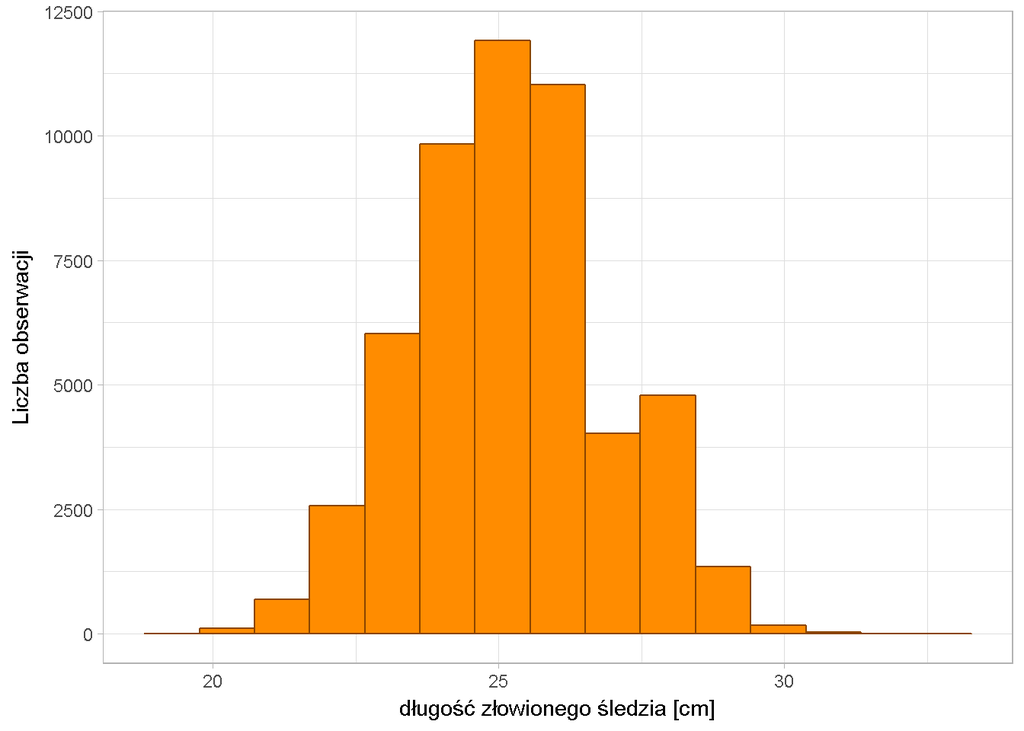

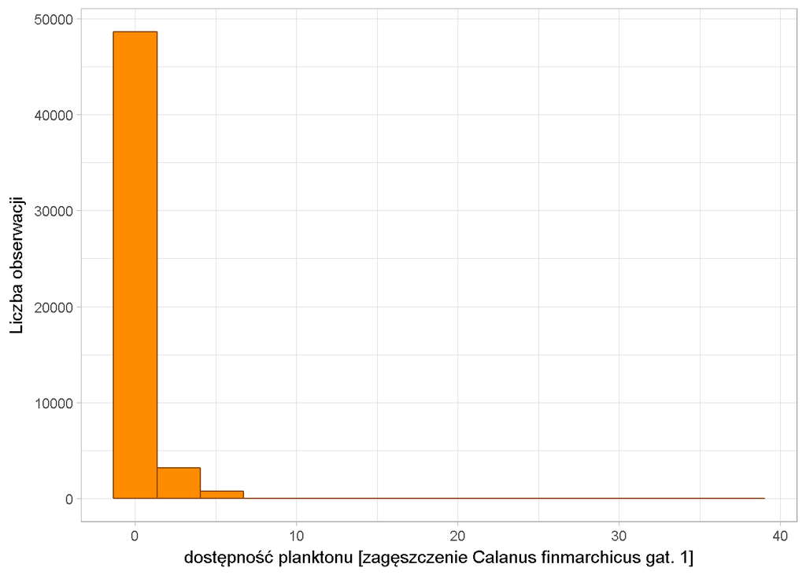

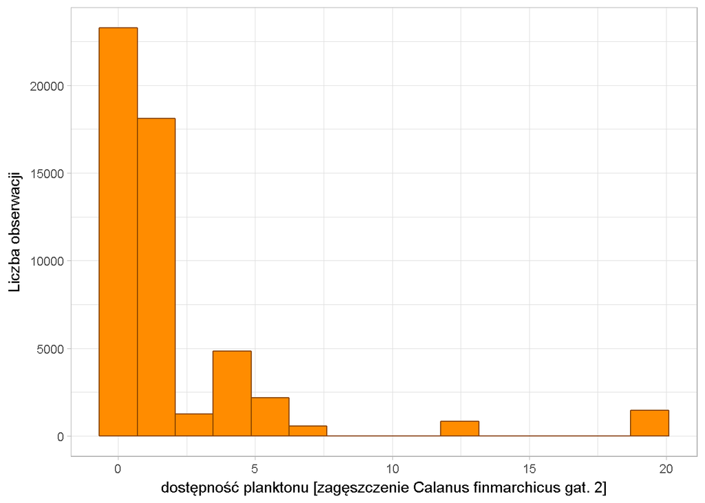

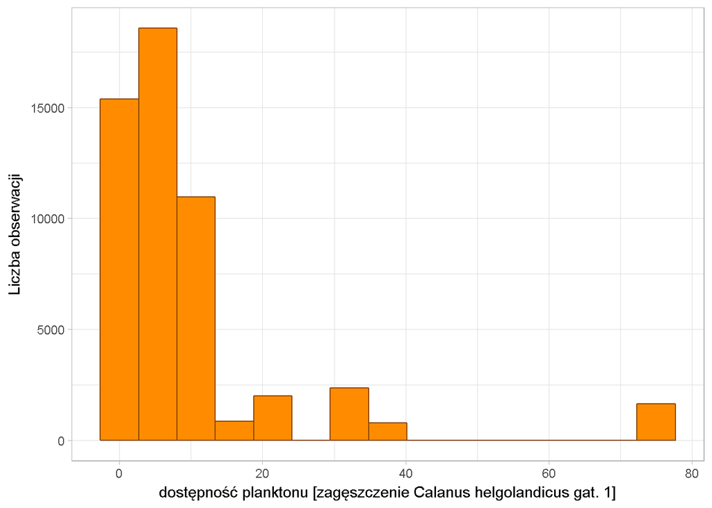

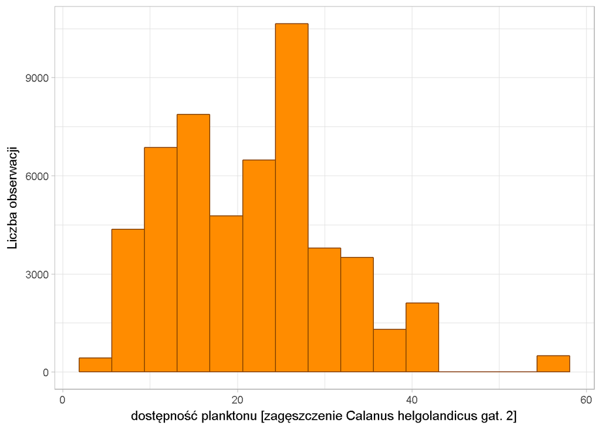

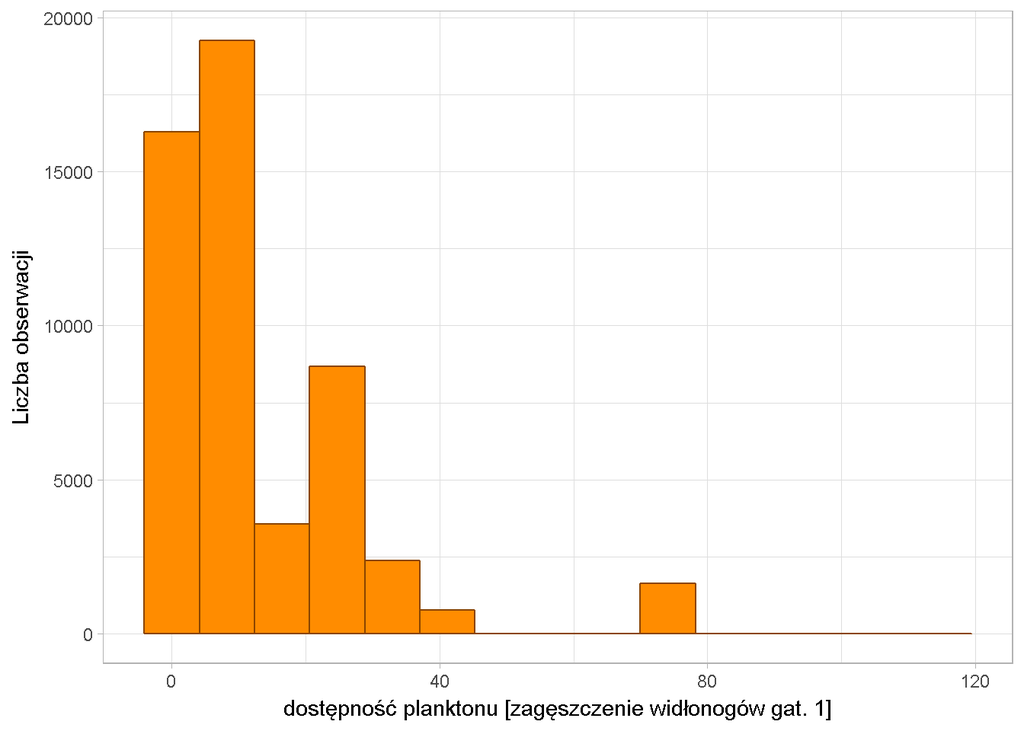

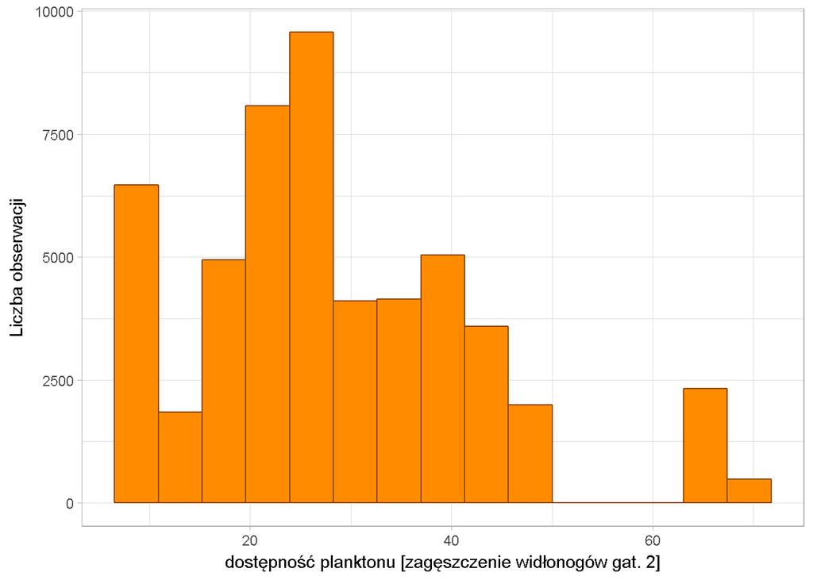

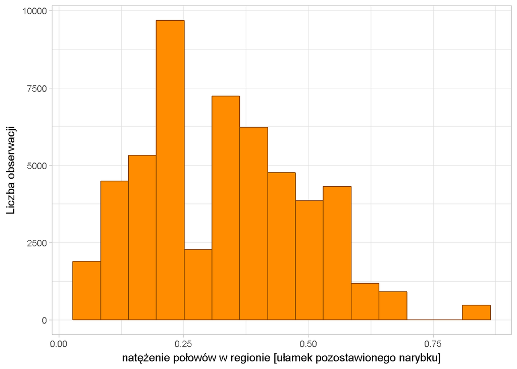

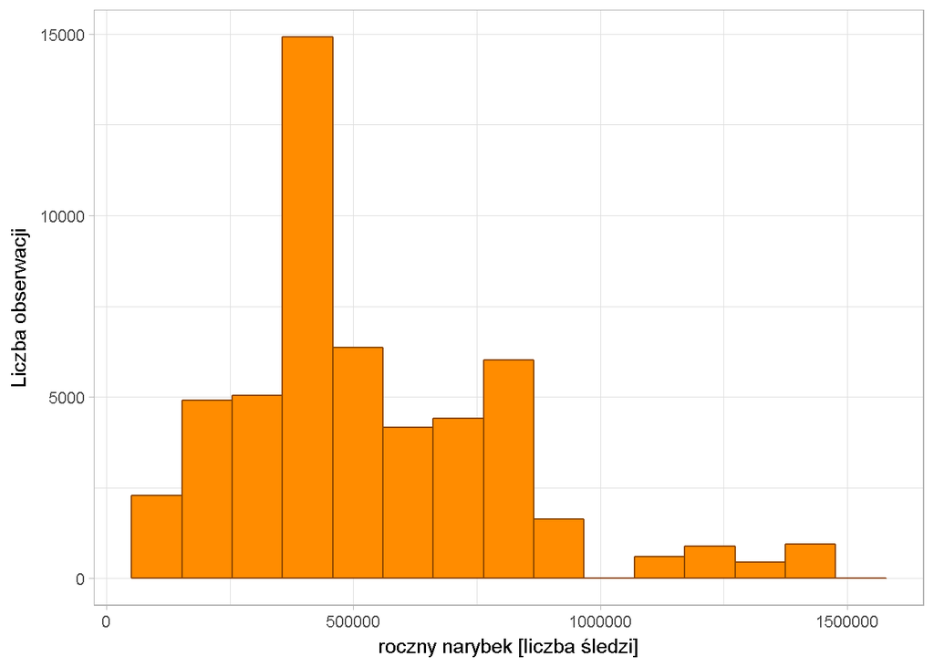

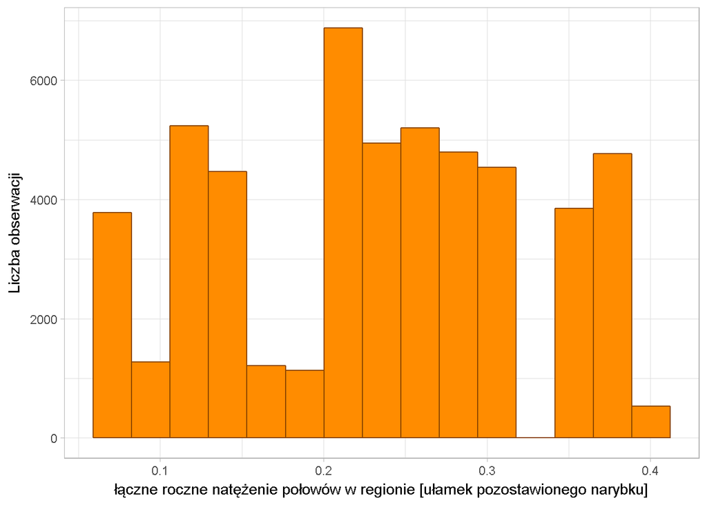

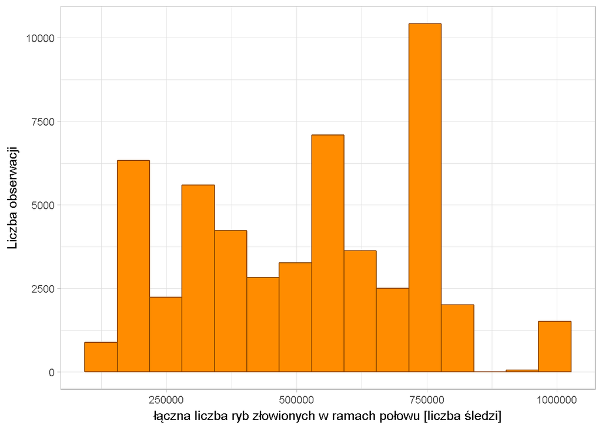

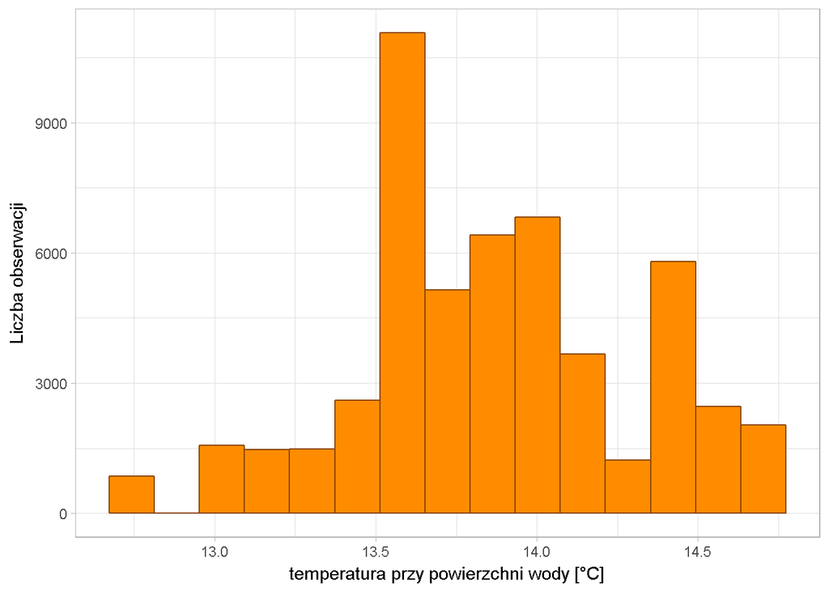

[3 more figures not shown]

```r
  sledzie_colnames <- c(colnames(sledzie_with_names[-1]))
  for (i in sledzie_colnames){
  print(ggplot(sledzie_with_names,aes(sledzie_with_names[i])) + geom_histogram(bins = 15, col="darkorange4", fill="darkorange") + xlab(i) + ylab("Liczba obserwacji") + theme_light())
  }
```

## Zmiana rozmariu śledzi w czasie

Sprawdźmy, jak zmieniał się rozmiar śledzi w czasie:

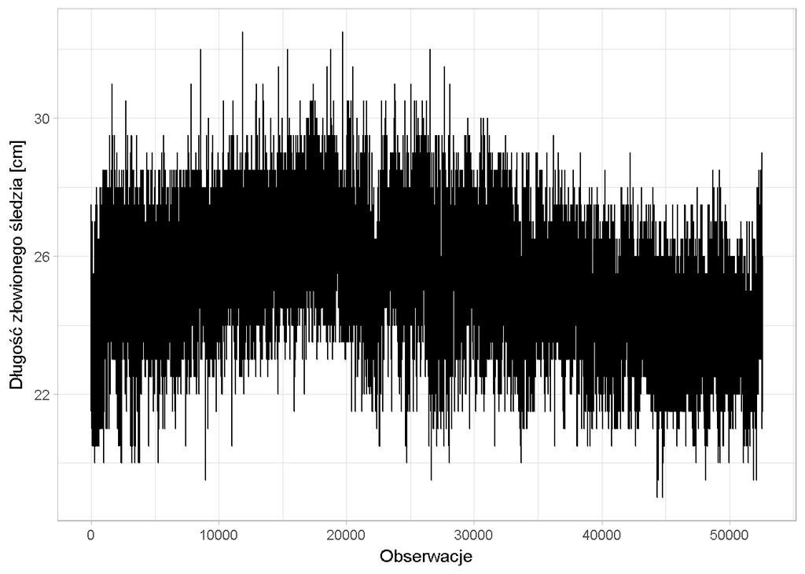

```r
print(ggplot(sledzie, aes(x=X, y=length))+ geom_line() + xlab("Obserwacje") + ylab("Długość złowionego śledzia [cm]") + theme_light())
```

```r
ggplotly( ggplot(sledzie, aes(x=X, y=length))+ geom_smooth() + xlab("Obserwacje") + ylab("Długość złowionego śledzia [cm]") + theme_light())
```

[interactive chart not shown]

## Korelacje między atrybutami

Dzięki macierzy korelacji możemy sprawdzić, które atrybuty są do siebie podobne.

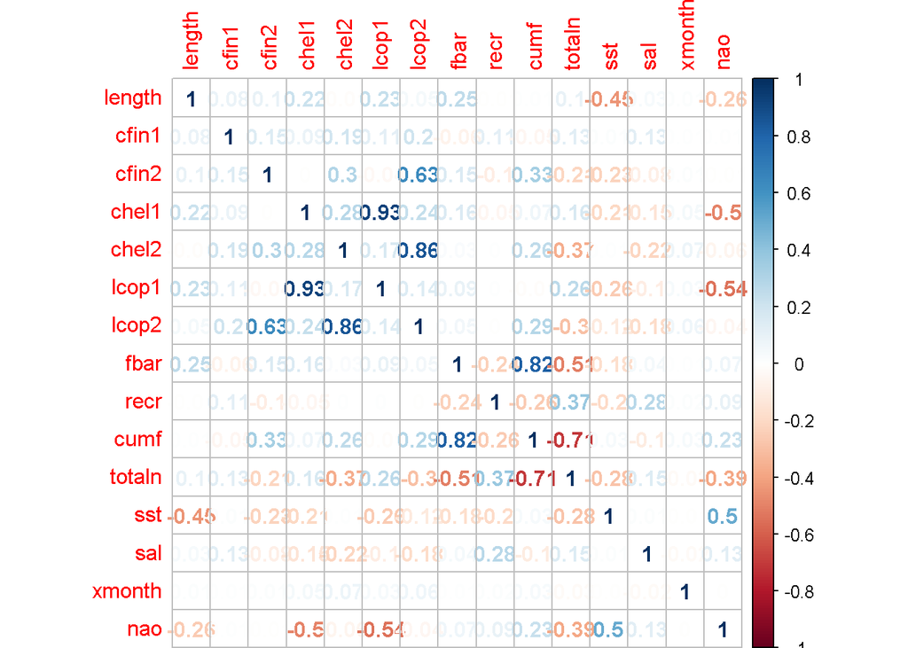

```r
corrplot(cor(sledzie[-1]), method="number")
```

Atrybutami silnie skorelowanymi są:

- [lcop1-chel1]
- [lcop2-chel2]
- [cumf-fbar]

```r
sledzie <- sledzie[c(-6,-7,-10)]
sledzie_with_names <- sledzie_with_names[c(-6,-7,-10)]
```

## Regresja

```r
sledzie <- sledzie[-1]
sledzie_regress <- createDataPartition(y = sledzie$length, p = 0.70, list = FALSE)
sledzie_train <- sledzie[sledzie_regress,]
sledzie_test <-  sledzie[-sledzie_regress,]
```

Uczenie metodą random forest.

```r
control <- trainControl( method = "repeatedcv",number = 3, repeats = 6)
trn <- train(length~.,
              data = sledzie_train,
              method = "rf",
              trControl = control,
              importance =TRUE,
              ntree = 10)
```

Jakość predykcji:

```r
trn
```

```
## Random Forest
##
## 36810 samples
##    11 predictor
##
## No pre-processing
## Resampling: Cross-Validated (3 fold, repeated 6 times)
## Summary of sample sizes: 24540, 24540, 24540, 24540, 24540, 24540, ...
## Resampling results across tuning parameters:
##
##   mtry  RMSE      Rsquared
##    2    1.164114  0.5024644
##    6    1.154547  0.5110710
##   11    1.162307  0.5053514
##
## RMSE was used to select the optimal model using  the smallest value.
## The final value used for the model was mtry = 6.
```

## Analiza ważności atrybutów

Poniższy diagram prezentuje ważność poszczególnych atrybutów.

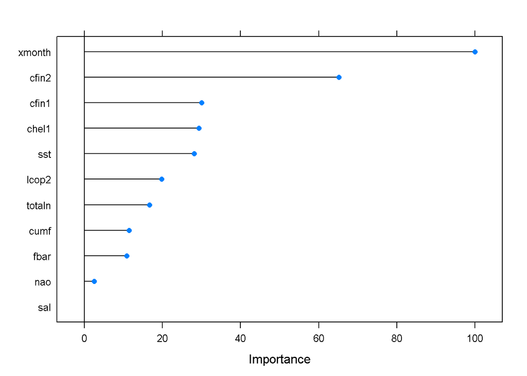

```r
plot(varImp(trn))
```